# Preparação

```python
# from google.colab import drive
# drive.mount('/content/drive')
```

```python
# requirements:

# análise e manipulação de dados
import pandas as pd
import numpy as np

# visualização de dados
import matplotlib.pyplot as plt

# pré-processamento de dados
from sklearn.preprocessing import StandardScaler

# redução de dimensionalidade
from sklearn.decomposition import PCA

# modelos de ML
from sklearn.neural_network import MLPClassifier
from sklearn.cluster import KMeans, AgglomerativeClustering
from sklearn.neighbors import KNeighborsClassifier
from sklearn.ensemble import RandomForestClassifier

# avaliação de modelos
from sklearn.model_selection import StratifiedGroupKFold, cross_val_score, cross_val_predict
from sklearn.metrics import confusion_matrix, ConfusionMatrixDisplay
from sklearn.model_selection import GridSearchCV
from sklearn.metrics import make_scorer, accuracy_score
from sklearn.metrics import adjusted_rand_score, silhouette_score
from sklearn.metrics import davies_bouldin_score, calinski_harabasz_score
```

# Pré-processamento

```python
# carregamento do csv
# caminho = "/content/drive/My Drive/content/prova2/sinais.csv"
caminho = "sinais.csv"
df_csv = pd.read_csv(caminho)
```

```python
# visualizar quantidade de linha e colunas
df_csv.shape
```

```
(2502, 7)
```

```python
# 5 primeiras linhas
df_csv.head()
```

|  | file_name | width | height | duration_sec | num_frames | sinal | interprete |
| --- | --- | --- | --- | --- | --- | --- | --- |
| 0 | Adição_AP_10.json | 738 | 1008 | 4.533333 | 136 | Adição | Alexson |
| 1 | Adição_AP_1.json | 774 | 1006 | 4.766667 | 143 | Adição | Alexson |
| 2 | Adição_AP_2.json | 760 | 1002 | 4.433333 | 133 | Adição | Alexson |
| 3 | Adição_AP_3.json | 762 | 1000 | 4.933333 | 148 | Adição | Alexson |
| 4 | Adição_AP_4.json | 764 | 1004 | 4.600000 | 138 | Adição | Alexson |

## Análise inicial

Buscar valores ausentes, duplicados, outliers e tratá-los se necessário

```python
df_csv.isnull().sum()
```

```
file_name       1
width           0
height          0
duration_sec    0
num_frames      0
sinal           0
interprete      0
dtype: int64
```

Há um dado nulo em "file_name". Como a base deveria ter 2500 arquivos e atualmente tem 2502, decidi removê-lo

```python
df_csv.dropna(inplace=True)
```

```python
df_csv.isnull().sum() # conferindo após o drop
```

```
file_name       0
width           0
height          0
duration_sec    0
num_frames      0
sinal           0
interprete      0
dtype: int64
```

```python
df_csv.duplicated().sum()
```

```
np.int64(0)
```

Não há valores duplicados

### Análise das colunas

```python
df_csv.info()
```

```
<class 'pandas.core.frame.DataFrame'>
Index: 2501 entries, 0 to 2501
Data columns (total 7 columns):
 #   Column        Non-Null Count  Dtype
---  ------        --------------  -----
 0   file_name     2501 non-null   object
 1   width         2501 non-null   int64
 2   height        2501 non-null   int64
 3   duration_sec  2501 non-null   float64
 4   num_frames    2501 non-null   int64
 5   sinal         2501 non-null   object
 6   interprete    2501 non-null   object
dtypes: float64(1), int64(3), object(3)
memory usage: 156.3+ KB
```

- file_name: nome do arquivo
- width: largura do vídeo
- height: altura do vídeo
- duration_sec: duração do vídeo em segundos
- num_frames: quantidade de frames do vídeo
- sinal: sinal sendo sinalizado no vídeo
- interprete: nome da pessoa que aparece no vídeo

```python
df_csv.sinal.value_counts()
```

```
sinal
Adição              101
Aluno               101
Antropologia        100
Apontador           100
Apostila            100
Biologia            100
Capítulo            100
Classe              100
Coerência           100
Ensinar             100
Coesão              100
Colega              100
Conceito            100
Contexto            100
Curso               100
Dicionário          100
Disciplina          100
Física              100
Escola              100
Estudar             100
Filosofia           100
História            100
Geografia           100
Ângulo              100
Bolsa de Estudos     99
Name: count, dtype: int64
```

A base parece bem balanceada em relação ao atributo alvo. Apenas 2 sinais têm uma instância a mais que os demais, e um tem uma a menos

```python
df_csv.shape
```

```
(2501, 7)
```

Inicialmente temos poucas colunas e algumas delas não possuem informações tão úteis para o objetivo. Além de dropar algumas, posteriormente também vou criar mais algumas considerando os arquivos JSON. Antes, vou normalizar os dados nominais

### Normalização das strings

A fim de garantir que diferentes representações de caracteres equivalentes sejam tratadas de forma consistente, vou normalizar os atributos nominais da base

```python
import unicodedata

def remove_acentos(texto: str) -> str:
    if isinstance(texto, str):
        # normaliza pra decompor acentos
        nfkd_form = unicodedata.normalize("NFKD", texto)
        # filtra tudo que não for "mark, nonspacing" (ou seja, acentos)
        return "".join([c for c in nfkd_form if not unicodedata.category(c) == "Mn"])
    return texto
```

```python
# normalizando as colunas "file_name" e "interprete"
# não normalizei "sinal" por ser o atributo alvo

df_csv["file_name"] = df_csv["file_name"].apply(remove_acentos)
df_csv["interprete"] = df_csv["interprete"].apply(remove_acentos)

print(df_csv.head())
```

```
           file_name  width  height  duration_sec  num_frames   sinal  \
0  Adicao_AP_10.json    738    1008      4.533333         136  Adição
1   Adicao_AP_1.json    774    1006      4.766667         143  Adição
2   Adicao_AP_2.json    760    1002      4.433333         133  Adição
3   Adicao_AP_3.json    762    1000      4.933333         148  Adição
4   Adicao_AP_4.json    764    1004      4.600000         138  Adição

  interprete
0    Alexson
1    Alexson
2    Alexson
3    Alexson
4    Alexson
```

### Análise dos dados com Profiling

```python
pip install ydata-profiling
```

```python
import ydata_profiling
from ydata_profiling import ProfileReport

profile = ProfileReport(df_csv)
profile.to_notebook_iframe()
```

```
100%|███████████████████████████████████████████████████████████████████████████████████████████████████████████████████████████████████████████████████| 7/7 [00:00<00:00, 75.23it/s]
```

[interactive chart not shown]

O profiling alertou que a coluna duraction_sec é altamente correlacionada com num_frames (já que em todo vídeo um segundo tem 30 frames); vou remover uma delas.

Além disso, height e width também são altamente correlacionadas, dado que se trata de resolução de vídeo, mas não vejo necessidade de removê-las, pelo menos não inicialmente. E essas duas também estão altamente correlacionadas com a coluna interprete, provavelmente por cada interprete ter gravado os vídeos de uma mesma maneira única (dispotivos e formatos diferentes).

No mais, as colunas sinal e interprete estão uniformemente distribuídas e file_name tem valores únicos

```python
df_csv_dsdrop = df_csv.drop("duration_sec", axis=1)
```

Conferindo duplicatas sem a coluna "duration_sec"

```python
dupes = df_csv_dsdrop.duplicated()
sum(dupes)
```

```
0
```

```python
df_csv_dsdrop.shape
```

```
(2501, 6)
```

## JSON -> Dataframe

Dado que o csv é a tabela principal, e cada instância dessa tabela tem um arquivo json correspondente, decidi expandir os dados em uma estrutura tabular. Dessa forma, cada frame pode ser ligado ao identificador do sinal do csv.

Para adiantar umas coisas, ao transformar os arquivos json em um dataframe, já vou incluir apenas os keypoints que têm visibilidade >= 50% no arquivo. Isso vai deixar o dataframe com menos linhas

```python
import os
import json
import csv

# ---------- CONFIG ----------
caminho_json = "Sinais"                # pasta com os JSONs
output_csv = "processed/df_json_cleaned.csv"
EPSILON = 0.4                         # considerar invisível se <= 0.4
THRESH = 0.5                           # remover se >= 50% invisível
# -----------------------------

# --- prepara arquivo de saída (remove se existir) ---
meta_map = {}
os.makedirs(os.path.dirname(output_csv) or ".", exist_ok=True)
if os.path.exists(output_csv):
    os.remove(output_csv)

header = ["file_name", "frame", "id", "x", "y", "z", "visibility"]

with open(output_csv, "w", newline="", encoding="utf-8") as out_f:
    writer = csv.writer(out_f)
    writer.writerow(header)

    files = sorted(os.listdir(caminho_json))
    for idx, fname in enumerate(files, start=1):
        if not fname.lower().endswith(".json"):
            continue

        file_path = os.path.join(caminho_json, fname)
        try:
            with open(file_path, "r", encoding="utf-8") as f:
                json_data = json.load(f)
        except Exception as e:
            print(f"Erro lendo {fname}: {e}")
            continue

        frames = json_data.get("frames", [])
        # 1ª passagem: contar total e invisível por id
        total_counts = {}
        invis_counts = {}
        for fr in frames:
            for kp in fr.get("keypoints", []):
                kid = kp["id"]
                total_counts[kid] = total_counts.get(kid, 0) + 1
                if kp.get("visibility", 0) <= EPSILON:
                    invis_counts[kid] = invis_counts.get(kid, 0) + 1

        # ids a remover neste arquivo
        ids_to_drop = {kid for kid, tot in total_counts.items()
                       if (invis_counts.get(kid, 0) / tot) >= THRESH}

        # 2ª passagem: escrever apenas keypoints que NÃO estão em ids_to_drop
        for fr in frames:
            fnum = fr.get("frame")
            for kp in fr.get("keypoints", []):
                kid = kp["id"]
                if kid in ids_to_drop:
                    continue
                x = kp.get("x")
                y = kp.get("y")
                z = kp.get("z")
                vis = kp.get("visibility")
                writer.writerow([fname, fnum, kid, x, y, z, vis])

        # feedback simples de progresso
        if idx % 100 == 0:
            print(f"Processados {idx} arquivos...")

print("Processamento concluído. Resultado em:", output_csv)
```

```
Processados 100 arquivos...
Processados 200 arquivos...
Processados 300 arquivos...
Processados 400 arquivos...
Processados 500 arquivos...
Processados 600 arquivos...
Processados 700 arquivos...
Processados 800 arquivos...
Processados 900 arquivos...
Processados 1000 arquivos...
Processados 1100 arquivos...
Processados 1200 arquivos...
Processados 1300 arquivos...
Processados 1400 arquivos...
Processados 1500 arquivos...
Processados 1600 arquivos...
Processados 1700 arquivos...
Processados 1800 arquivos...
Processados 1900 arquivos...
Processados 2000 arquivos...
Processados 2100 arquivos...
Processados 2200 arquivos...
Processados 2300 arquivos...
Processados 2400 arquivos...
Processados 2500 arquivos...
Processamento concluído. Resultado em: processed/df_json_cleaned.csv
```

```python
df_json = pd.read_csv("processed/df_json_cleaned.csv")
```

```python
df_json.head()
```

|  | file_name | frame | id | x | y | z | visibility |
| --- | --- | --- | --- | --- | --- | --- | --- |
| 0 | Adição_AP_1.json | 0 | 0 | 438 | 184 | -1.44 | 1.0 |
| 1 | Adição_AP_1.json | 0 | 1 | 462 | 154 | -1.36 | 1.0 |
| 2 | Adição_AP_1.json | 0 | 2 | 474 | 154 | -1.36 | 1.0 |
| 3 | Adição_AP_1.json | 0 | 3 | 484 | 154 | -1.36 | 1.0 |
| 4 | Adição_AP_1.json | 0 | 4 | 421 | 155 | -1.36 | 1.0 |

```python
df_json.duplicated().sum()
```

```
np.int64(0)
```

Nenhuma duplicata

Esse dataframe também possui acentos. Vamos removê-los da mesma forma do df_csv:

```python
# normalizando a coluna "file_name"
# essa tabela não será utilizada para treinar modelos, mas vai servir para o merge (etapa seguinte)
df_json["file_name"] = df_json["file_name"].apply(remove_acentos)

print(df_json.head())
```

```
          file_name  frame  id    x    y     z  visibility
0  Adicao_AP_1.json      0   0  438  184 -1.44         1.0
1  Adicao_AP_1.json      0   1  462  154 -1.36         1.0
2  Adicao_AP_1.json      0   2  474  154 -1.36         1.0
3  Adicao_AP_1.json      0   3  484  154 -1.36         1.0
4  Adicao_AP_1.json      0   4  421  155 -1.36         1.0
```

```python
df_json.shape
```

```
(7346183, 7)
```

### Merge JSON + CSV

Merge inner join entre o csv e o novo dataframe dos jsons pelo file_name

```python
df_final = pd.merge(df_json, df_csv_dsdrop, on="file_name", how="inner")
```

```python
# transformar em arquivo csv
df_final.to_csv("processed/df_final.csv", index=False)
```

```python
df_final.shape
```

```
(7346183, 12)
```

```python
df_final.duplicated().sum()
```

```
np.int64(0)
```

Não há duplicatas

```python
df_final.info()
```

```
<class 'pandas.core.frame.DataFrame'>
RangeIndex: 7346183 entries, 0 to 7346182
Data columns (total 12 columns):
 #   Column      Dtype
---  ------      -----
 0   file_name   object
 1   frame       int64
 2   id          int64
 3   x           int64
 4   y           int64
 5   z           float64
 6   visibility  float64
 7   width       int64
 8   height      int64
 9   num_frames  int64
 10  sinal       object
 11  interprete  object
dtypes: float64(2), int64(7), object(3)
memory usage: 672.6+ MB
```

As novas colunas "x" e "y" são equivalentes às "width" e "height" do arquivo csv inicial, respectivamente. Antes de remover as redundâncias, vou normalizar x e y em função de width e height

```python
# normalizar x e y em função da largura e altura
df_final["x"] = df_final["x"] / df_final["width"].replace(0, 1)
df_final["y"] = df_final["y"] / df_final["height"].replace(0, 1)
```

E agora remover as redundâncias:

```python
# drop em width e height
df_final = df_final.drop(["width", "height"], axis=1)
```

```python
df_final.drop(["z"], axis=1, inplace=True)
```

Para adicionar mais informações que possam ajudar nos treinamentos dos modelos posteriormente, vou criar colunas relacionadas a algumas estatísticas dos dados:

- velocidade do movimento: média/std
- amplitude
- mínimos e máximos

em relação aos ids.

Visto que os ids 0 a 10 marcam o rosto da pessoa no vídeo, decidi removê-los já que dificilmente faria alguma diferença dado que os rostos estão borrados. Essa remoção também ajuda a diminuir a quantidade de colunas final. Além disso, também desconsiderei os ids posteriores ao 22, por se tratarem de pontos da parte inferior do corpo, que muitas vezes não aparecem nos vídeos e não são relevantes para o significado do sinal em si.

```python
def gerar_features_movimento(df):
    """
    Cria features de velocidade (média/std), amplitude, min e max
    para cada keypoint (x e y), agrupadas por file_name.
    Considera apenas keypoints com id de 11 a 22.

    df: DataFrame com colunas [file_name, frame, id, x, y, sinal, interprete]
    """
    features = []

    # filtra apenas keypoints de interesse
    df = df[df["id"].between(11, 22)]

    # itera por instância (vídeo)
    for fname, grupo in df.groupby("file_name"):
        row = {"file_name": fname}
        # metadados
        row["sinal"] = grupo["sinal"].iloc[0]
        row["interprete"] = grupo["interprete"].iloc[0]

        # itera por keypoint
        for kp_id, kp_grp in grupo.groupby("id"):
            kp_grp = kp_grp.sort_values("frame")

            # velocidade: diferença entre frames consecutivos
            dx = kp_grp["x"].diff().dropna()
            dy = kp_grp["y"].diff().dropna()

            row[f"kp_{kp_id}_vx_mean"] = dx.mean()
            row[f"kp_{kp_id}_vx_std"]  = dx.std()
            row[f"kp_{kp_id}_vy_mean"] = dy.mean()
            row[f"kp_{kp_id}_vy_std"]  = dy.std()

            # amplitude de movimento
            row[f"kp_{kp_id}_x_amp"] = kp_grp["x"].max() - kp_grp["x"].min()
            row[f"kp_{kp_id}_y_amp"] = kp_grp["y"].max() - kp_grp["y"].min()

            # valores mínimos e máximos
            row[f"kp_{kp_id}_x_min"] = kp_grp["x"].min()
            row[f"kp_{kp_id}_x_max"] = kp_grp["x"].max()
            row[f"kp_{kp_id}_y_min"] = kp_grp["y"].min()
            row[f"kp_{kp_id}_y_max"] = kp_grp["y"].max()

        features.append(row)

    return pd.DataFrame(features)
```

Aqui, o dataframe volta a ter as 2501 linhas

```python
df_features_mov = gerar_features_movimento(df_final)

print("Shape final:", df_features_mov.shape)
```

```
Shape final: (2501, 123)
```

```python
df_features_mov.head()
```

|  | file_name | sinal | interprete | kp_11_vx_mean | kp_11_vx_std | kp_11_vy_mean | kp_11_vy_std | kp_11_x_amp | kp_11_y_amp | kp_11_x_min | ... | kp_22_vx_mean | kp_22_vx_std | kp_22_vy_mean | kp_22_vy_std | kp_22_x_amp | kp_22_y_amp | kp_22_x_min | kp_22_x_max | kp_22_y_min | kp_22_y_max |
| --- | --- | --- | --- | --- | --- | --- | --- | --- | --- | --- | --- | --- | --- | --- | --- | --- | --- | --- | --- | --- | --- |
| 0 | Adicao_AP_1.json | Adição | Alexson | -0.000009 | 0.000662 | -0.000042 | 0.000566 | 0.010336 | 0.014911 | 0.803618 | ... | -0.000164 | 0.006001 | 0.000056 | 0.014827 | 0.198966 | 0.506958 | 0.394057 | 0.593023 | 0.323062 | 0.830020 |
| 1 | Adicao_AP_10.json | Adição | Alexson | -0.000010 | 0.000672 | -0.000022 | 0.000587 | 0.013550 | 0.013889 | 0.808943 | ... | -0.000161 | 0.007062 | 0.000169 | 0.014001 | 0.210027 | 0.482143 | 0.367209 | 0.577236 | 0.329365 | 0.811508 |
| 2 | Adicao_AP_2.json | Adição | Alexson | 0.000020 | 0.000629 | -0.000030 | 0.000640 | 0.013158 | 0.018962 | 0.810526 | ... | -0.000050 | 0.007162 | 0.000008 | 0.014490 | 0.201316 | 0.488024 | 0.386842 | 0.588158 | 0.313373 | 0.801397 |
| 3 | Adicao_AP_3.json | Adição | Alexson | 0.000000 | 0.000575 | -0.000020 | 0.000445 | 0.011811 | 0.011000 | 0.817585 | ... | -0.000009 | 0.006042 | -0.000014 | 0.013695 | 0.200787 | 0.454000 | 0.389764 | 0.590551 | 0.351000 | 0.805000 |
| 4 | Adicao_AP_4.json | Adição | Alexson | 0.000000 | 0.000692 | -0.000044 | 0.000590 | 0.015707 | 0.017928 | 0.808901 | ... | -0.000029 | 0.005848 | 0.000015 | 0.015294 | 0.201571 | 0.485060 | 0.387435 | 0.589005 | 0.324701 | 0.809761 |

5 rows × 123 columns

```python
df_features_mov.isnull().sum().sum()
```

```
np.int64(50)
```

O novo dataframe tem alguns dados ausentes. Visto que eles apareceram após a criação de novas colunas e que se dão pelo resultado dos cálculos (indicando que não existem dados para aquele atributo naquele vídeo), resolvi preenchê-los com 0

```python
df_features_mov = df_features_mov.fillna(0)
```

```python
df_features_mov.isnull().sum().sum()
```

```
np.int64(0)
```

```python
df_features_mov.shape
```

```
(2501, 123)
```

### Redução de dimensionalidade

Já removi algumas colunas que o profiling mostrou como sendo altamente correlacionadas. Porém, com o merge e outros fatores, agora tenho 123 colunas. Aplicar a técnica de análise de correlação de Pearson vai ajudar a eliminar mais colunas que carregam informações redundantes (manter apenas uma delas)

```python
# separar os dados e a variável alvo (rótulo)
dados_corr = df_features_mov.drop(columns=["sinal"], axis=1)
# também vou dar drop em file_name e interprete por serem variáveis nominais
# e para evitar data leakage futuramente
dados_corr = dados_corr.drop(columns=["file_name", "interprete"], axis=1)

rotulo_corr = df_features_mov["sinal"]
```

```python
# calcular matriz de correlação de pearson
# .abs() pega correlações positivas e negativas
matriz_corr = dados_corr.corr(method="pearson").abs()
```

```python
dados_corr.shape
```

```
(2501, 120)
```

```python
# selecionar apenas a parte superior da matriz de correlação (triângulo superior)
# cria-se uma matriz de booleanos em que o triângulo superior é todo preenchido com True
# e a diagonal principal e o triângulo inferior com False
# Depois utiliza isso para selecionar apenas o triângulo superior
triangulo_superior = matriz_corr.where(np.triu(np.ones(matriz_corr.shape), k=1).astype(bool))
triangulo_superior.shape
```

```
(120, 120)
```

Assim é possível identificar quais colunas têm alta correlação. Quando colunas tiverem correlação maior que 90%, serão removidas.

```python
# encontrar colunas com correlação maior que 0.90
limite_correlacao = 0.90
to_drop = [column for column in triangulo_superior.columns if any(triangulo_superior[column] > limite_correlacao)]

# remover essas colunas
dados_corr_filt = dados_corr.drop(columns=to_drop)

print(f"{len(to_drop)} colunas para remover por alta correlação")
```

```
64 colunas para remover por alta correlação
```

```python
# novo datarame sem essas colunas
df_corr_filt = pd.concat([dados_corr_filt, rotulo_corr], axis=1)

df_corr_filt.shape
```

```
(2501, 57)
```

Aplicando PCA:

```python
# separar novamente os dados da variável alvo (rótulo)
dados_pca = df_corr_filt.drop(columns=["sinal"])
rotulo_pca = df_corr_filt["sinal"]
```

Como PCA é sensível à escala das variáveis, se um atributo tiver valores muito grandes e outro atributo tiver valores muito pequenos, a variânvia do primeiro vai dominar a análise. Pra isso, vou aplicar standardScaler() pra normalizar. Essa função transforma os dados para que cada feature tenha média 0 e desvio padrão 1, o que garante que todas as variáveis tenham o mesmo peso na hora de calcular os componentes principais

```python
# normalizando os dados
scaler = StandardScaler()
dados_normalizados = scaler.fit_transform(dados_pca)
```

Aqui, escolhi preservar 95% da variância total dos dados originais, assim mantém a quantidade mínima de componentes nescessários pra poder preservar essa variância;

E com o método fit_transform, vou calcular os componentes principais com base na variância dos dados. Isso projeta os dados originais no novo sistema reduzido

```python
# aplicando o PCA mantendo 95% da variância
pca = PCA(n_components=0.95)
dados_pca_transformado = pca.fit_transform(dados_normalizados)

# vendo quantos componentes foram mantidos
print(f"{pca.n_components_} componentes mantidos.")
```

```
24 componentes mantidos.
```

## Treino e comparação de desempenho

Validação cruzada estratificada com a base reduzida quanto à dimensionalidade:

```python
# validação cruzada estratificada:

folds = 10 # 10 divisões
r_state = 42 # fixando random_state

# separa features, rótulos e grupos
X = dados_pca_transformado
y = rotulo_pca
groups = df_features_mov["interprete"]  # mesma ordem das instâncias

# validador estratificado por sinal, mas separado por intérprete
# shuffle=True pra embaralhar os dados antes de dividir
validador = StratifiedGroupKFold(n_splits=folds, shuffle=True, random_state=r_state)
```

```python
# modelos
modelo_rf = RandomForestClassifier(n_estimators=100, random_state=r_state)
modelo_mlp = MLPClassifier(max_iter=1000, random_state=r_state)
modelo_knn = KNeighborsClassifier(n_neighbors=5)
```

```python
# cross_val_score com grupos
f1_arvore = cross_val_score(modelo_rf, X, y, groups=groups, cv=validador, scoring="f1_macro")
f1_mlp = cross_val_score(modelo_mlp, X, y, groups=groups, cv=validador, scoring="f1_macro")
f1_knn = cross_val_score(modelo_knn, X, y, groups=groups, cv=validador, scoring="f1_macro")
```

```python
print("COM redução de dimensionalidade:")
print("F1 médio - Random Forest:", f1_arvore.mean())
print("F1 médio - MLP:", f1_mlp.mean())
print("F1 médio - KNN:", f1_knn.mean())
```

```
COM redução de dimensionalidade:
F1 médio - Random Forest: 0.3694422889264858
F1 médio - MLP: 0.42632416859477384
F1 médio - KNN: 0.2980345627210327
```

Vou verificar a acurácia de cada um:

```python
# calcular acurária de cada modelo:
scorer = make_scorer(accuracy_score)

acc_rf = cross_val_score(modelo_rf, X, y, groups=groups, cv=validador, scoring=scorer)
acc_mlp = cross_val_score(modelo_mlp, X, y, groups=groups, cv=validador, scoring=scorer)
acc_knn = cross_val_score(modelo_knn, X, y, groups=groups, cv=validador, scoring=scorer)

# resultados médios
print("Acurácia média - Random Forest:", acc_rf.mean())
print("Acurácia média - MLP:", acc_mlp.mean())
print("Acurácia média - KNN:", acc_knn.mean())
```

```
Acurácia média - Random Forest: 0.40266454183266936
Acurácia média - MLP: 0.46622948207171316
Acurácia média - KNN: 0.3354549800796813
```

Vou testar agora com a base antes da redução de dimensionalidade:

Definição de X e y + label encoder no atributo alvo

```python
from sklearn.preprocessing import LabelEncoder
# X é o array de tamanho (n_amostras, n_atributos) sem os atributos categóricos
X = df_features_mov.drop(columns=["file_name", "sinal", "interprete"])

# y é o array de tamanho (n_amostras,) com o rótulo (atributo alvo)
y = df_features_mov["sinal"]

# aplicar label encoder em y
le = LabelEncoder()
y_encoded = le.fit_transform(y)
```

F1-score:

```python
# cross_val_score com grupos
f1_arvore = cross_val_score(modelo_rf, X, y_encoded, groups=groups, cv=validador, scoring="f1_macro")
f1_mlp = cross_val_score(modelo_mlp, X, y_encoded, groups=groups, cv=validador, scoring="f1_macro")
f1_knn = cross_val_score(modelo_knn, X, y_encoded, groups=groups, cv=validador, scoring="f1_macro")

print("SEM redução de dimensionalidade:")
print("F1 médio - Random Forest:", f1_arvore.mean())
print("F1 médio - MLP:", f1_mlp.mean())
print("F1 médio - KNN:", f1_knn.mean())
```

```
SEM redução de dimensionalidade:
F1 médio - Random Forest: 0.4584832112456616
F1 médio - MLP: 0.4644210791140986
F1 médio - KNN: 0.3764208274826297
```

```python
acc_rf = cross_val_score(modelo_rf, X, y_encoded, groups=groups, cv=validador, scoring=scorer)
acc_mlp = cross_val_score(modelo_mlp, X, y_encoded, groups=groups, cv=validador, scoring=scorer)
acc_knn = cross_val_score(modelo_knn, X, y_encoded, groups=groups, cv=validador, scoring=scorer)

# resultados médios
print("Acurácia média - Random Forest:", acc_rf.mean())
print("Acurácia média - MLP:", acc_mlp.mean())
print("Acurácia média - KNN:", acc_knn.mean())
```

```
Acurácia média - Random Forest: 0.5053912350597609
Acurácia média - MLP: 0.5046055776892431
Acurácia média - KNN: 0.42461354581673305
```

MLP teve a média de F1 mais alta, o que indica que entre esses modelos ele é o que consegue balancear melhor precisão e recall, o que faz sentido já que o problema tem padrões não-lineares e as redes neurais conseguem capturar isso melhor. A diferença em relação ao Random Forest é pequena, o que também faz sentido já que os dados têm padrões que podem ser bem capturados por regras de decisão (os sinais são os mesmos, apenas realizados por pessoas diferentes). O KNN ficou bem menor, isso provavelmente se dá porque o KNN sofre em casos de alta dimensionalidade (o dataframe tem muitas colunas) e padrões complexos não-lineares. Mesmo com reajuste do valor de k, os resultados não foram muito diferentes.

Os resultados foram melhores sem a redução de dimensionalidade do que com com ela. Logo, decidi manter a base sem a redução pelo resto da prova.

Matrizes de confusão:

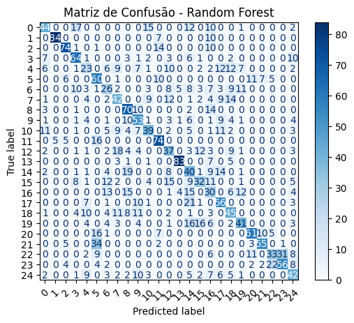

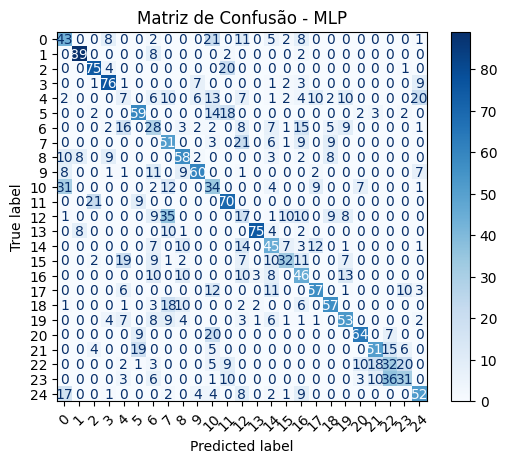

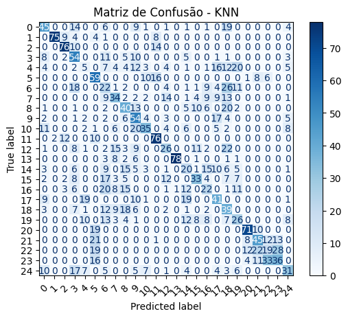

[figure not shown]

[figure not shown]

[figure not shown]

```python
%matplotlib inline

# lista de modelos e nomes para iteração
modelos = [
    ("Random Forest", modelo_rf),
    ("MLP", modelo_mlp),
    ("KNN", modelo_knn)
]

# pra cada modelo, gera a matriz de confusão e plota
for nome, modelo in modelos:
    # cross_val_predict retorna as previsões usando validação cruzada
    y_pred = cross_val_predict(modelo, X, y_encoded, groups=groups, cv=validador)

    # matriz de confusão
    cm = confusion_matrix(y_encoded, y_pred, labels=np.unique(y_encoded))

    # plotando a matriz
    disp = ConfusionMatrixDisplay(confusion_matrix=cm, display_labels=np.unique(y_encoded))
    disp.plot(cmap=plt.cm.Blues, xticks_rotation=45)
    plt.title(f"Matriz de Confusão - {nome}")
    plt.show()
```

Observação: no começo dessa etapa eu havia aplicado o GridSearch para obter os melhores parâmetros:

```python
# definição dos hiperparâmetros para cada modelo
parametros = {
    "RandomForest": {
        "model": RandomForestClassifier(random_state=r_state),
        "params": {
            "n_estimators": [100, 200, 300],
            "max_depth": [None, 10, 20],
            "min_samples_split": [2, 5]
        }
    },
    "KNN": {
        "model": KNeighborsClassifier(),
        "params": {
            "n_neighbors": [3, 5, 7, 9],
            "weights": ["uniform", "distance"],
            "metric": ["euclidean", "manhattan"]
        }
    },
    "MLP": {
        "model": MLPClassifier(max_iter=1000, random_state=r_state),
        "params": {
            "hidden_layer_sizes": [(50,), (100,), (100, 50)],
            "activation": ["relu", "tanh"],
            "alpha": [0.0001, 0.001, 0.01],
            "learning_rate": ["constant", "adaptive"]
        }
    }
}

# lista pra salvar os resultados
resultados = []

# loop pra aplicar GridSearch em cada modelo
for nome, conteudo in parametros.items():
    print(f"\nRodando GridSearch para {nome}...")

    grid = GridSearchCV(
        estimator=conteudo["model"],
        param_grid=conteudo["params"],
        scoring="f1_macro",
        cv=validador,
        n_jobs=-1
    )

    grid.fit(X, y, groups=groups)

    resultados.append({
        "Modelo": nome,
        "Melhores parâmetros": grid.best_params_,
        "Melhor F1": grid.best_score_
    })

# converte em dataframe pra visualizar
df_resultados = pd.DataFrame(resultados)
print("\n=== Resultados Finais ===")
print(df_resultados)
```

[output not shown]

Mas como a execução estava demorando bastante, optei por reduzir um pouco e obter resultados aproximados.

```python
df_resultados.head()
```

[output not shown]

## K-means e hierárquico

```python
# normaliza
scaler = StandardScaler()
X_scaled = scaler.fit_transform(X)

# K-means
kmeans = KMeans(n_clusters=len(df_features_mov["sinal"].unique()), random_state=42, n_init=18)
labels_kmeans = kmeans.fit_predict(X_scaled)

# Cluster hierárquico (Ward linkage)
hier = AgglomerativeClustering(n_clusters=len(df_features_mov["sinal"].unique()), linkage="ward")
labels_hier = hier.fit_predict(X_scaled)

# Avaliação com métricas externas (usam os rótulos reais)
y_true = df_features_mov["sinal"]
print("K-means ARI:", adjusted_rand_score(y_true, labels_kmeans))
print("Hierárquico ARI:", adjusted_rand_score(y_true, labels_hier))

# Avaliação interna (sem rótulo) – quão bem os clusters se separam
print("K-means Silhouette:", silhouette_score(X_scaled, labels_kmeans))
print("Hierárquico Silhouette:", silhouette_score(X_scaled, labels_hier))
```

```
K-means ARI: 0.1621965429694299
Hierárquico ARI: 0.1554757438581443
K-means Silhouette: 0.15319908167157792
Hierárquico Silhouette: 0.14493358434858272
```

Avaliação do K-means com o valor de K no teste do cotovelo e, com esse valor, comparar com o hierárquico

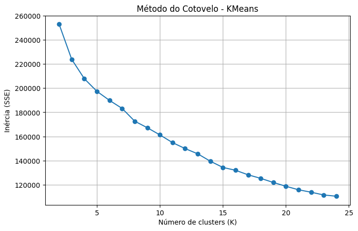

```python
%matplotlib inline

# lista para armazenar a inércia
inertias = []
K_range = range(2, 25)

for k in K_range:
    kmeans = KMeans(n_clusters=k, random_state=42, n_init=18)
    kmeans.fit(X_scaled)
    inertias.append(kmeans.inertia_)

# gráfico do cotovelo
plt.figure(figsize=(8,5))
plt.plot(K_range, inertias, marker='o')
plt.xlabel("Número de clusters (K)")
plt.ylabel("Inércia (SSE)")
plt.title("Método do Cotovelo - KMeans")
plt.grid(True)
plt.show()
```

Quanto K está entre 5 e 10 a curva começa a estabilizar mais. Vou escolher K = 7.

```python
# número de clusters definido pelo cotovelo
k_otimo = 7

# KMeans com K=7
kmeans = KMeans(n_clusters=k_otimo, random_state=42, n_init=18)
labels_kmeans = kmeans.fit_predict(X_scaled)

# Hierárquico (Ward) com K=7
hier = AgglomerativeClustering(n_clusters=k_otimo, linkage="ward")
labels_hier = hier.fit_predict(X_scaled)

# Avaliação
y_true = df_features_mov["sinal"]

print("== Comparação com K=7 ==")
print("K-means ARI:", adjusted_rand_score(y_true, labels_kmeans))
print("Hierárquico ARI:", adjusted_rand_score(y_true, labels_hier))

print("K-means Silhouette:", silhouette_score(X_scaled, labels_kmeans))
print("Hierárquico Silhouette:", silhouette_score(X_scaled, labels_hier))
```

```
== Comparação com K=7 ==
K-means ARI: 0.08785303386323744
Hierárquico ARI: 0.05308629685651954
K-means Silhouette: 0.14974655980585327
Hierárquico Silhouette: 0.18954965862533785
```

Nos resultados anteriores (com k = número de classes) o ARI foi razoavelmente próximo pros dois modelos, o que indica que eles chegaram a uma estrutura de clusters mais alinhada com os rótulos reais. O sillhouette ficou baixo, mas próximo também entre os dois, mostrando que os clusters não se separam bem de forma específica.

Com k fixado em 7 o ARI caiu bastante, ou seja, nesse valor os clusters se afastaram dos rótulos reais (as classes não são bem representadas com 7 clusters). Já o silhouette melhorou pro hierárquico, mostrando que mesmo setando menos alinhado aos rótulos, o hierárquico conseguiu formar clusters mais bem separados internamente. Pro k-means o silhouette se manteve parecido.

Esses resultados são coerentes já que quando usamos o número de clusters = número de classes reais, os métodos ficam mais próximos da verdade (ARI maior).

Próximo passo: Na execução do Hierárquico, variar métodos do linkage com o mesmo valor de k. Optei por fazer os 3.

```python
k_otimo = 7

# linkage = ward
hier_ward = AgglomerativeClustering(n_clusters=k_otimo, linkage="ward")
labels_hier_ward = hier_ward.fit_predict(X_scaled)

# linkage = complete
hier_complete = AgglomerativeClustering(n_clusters=k_otimo, linkage="complete")
labels_hier_complete = hier_complete.fit_predict(X_scaled)

# linkage = average
hier_average = AgglomerativeClustering(n_clusters=k_otimo, linkage="average")
labels_hier_average = hier_average.fit_predict(X_scaled)

# métricas
print("== Hierárquico com K=7 ==")
print("Ward   - ARI:", adjusted_rand_score(y_true, labels_hier_ward))
print("Ward   - Silhouette:", silhouette_score(X_scaled, labels_hier_ward))

print("Complete - ARI:", adjusted_rand_score(y_true, labels_hier_complete))
print("Complete - Silhouette:", silhouette_score(X_scaled, labels_hier_complete))

print("Average  - ARI:", adjusted_rand_score(y_true, labels_hier_average))
print("Average  - Silhouette:", silhouette_score(X_scaled, labels_hier_average))
```

```
== Hierárquico com K=7 ==
Ward   - ARI: 0.05308629685651954
Ward   - Silhouette: 0.18954965862533785
Complete - ARI: 0.0007692023477013102
Complete - Silhouette: 0.27237871026614874
Average  - ARI: 1.874954963546379e-05
Average  - Silhouette: 0.5365035578330963
```

WARD:

- ARI = 0.053 é muito baixo, então o agrupamento não reproduziu bem a estrutura real das classes;
- Silhouette = 0.189 também reflete uma separação fraca

COMPLETE:

- ARI = 0.00077 é ainda mais baixo, praticamente aleatório, ou seja, não conseguiu agrupar de forma consistente com os rótulos verdadeiros;
- Silhouette = 0.272 foi melhor que o Ward, os grpos ficaram mais coesos e separados mesmo sem corresponder bem às classes reais

AVERAGE:

- ARI = 0.0000187 muito próximo de zero, a correspondência com as classes pode ser considerada inexistente
- Silhouette = 0.536 foi o melhor resultado de separação interna entre todos os métodos, os clusters ficaram bem definidos

#### Comparação final

Todos os métodos ficaram com ARI baixo, indicando que nenhum agrupamento conseguiu reproduzir bem as classes reais. Nessa medida, o k-means foi melhor que qualquer versão do hierárquico.

Na silhouette, o hierárquico average se destacou mostrando grande separação e coesão dos grupos formados (mesmo que não batam com as classes reais), e o complete também foi relativamente bom (superior ao k-means, pelo menos)

Vou comparar com Davies Bouldin e Calinski Harabasz:

```python
# testando e comparando com outros tipos de índices

# lista de modelos
modelos = {
    "KMeans": KMeans(n_clusters=7, random_state=42, n_init=18),
    "Hierárquico-Ward": AgglomerativeClustering(n_clusters=7, linkage="ward"),
    "Hierárquico-Complete": AgglomerativeClustering(n_clusters=7, linkage="complete"),
    "Hierárquico-Average": AgglomerativeClustering(n_clusters=7, linkage="average"),
}

# armazena resultados
resultados = []

for nome, modelo in modelos.items():
    labels = modelo.fit_predict(X_scaled)

    sil = silhouette_score(X_scaled, labels)
    db = davies_bouldin_score(X_scaled, labels)
    ch = calinski_harabasz_score(X_scaled, labels)

    resultados.append({
        "Modelo": nome,
        "Silhouette": sil,
        "Davies-Bouldin": db,
        "Calinski-Harabasz": ch
    })

# converte em dataframe para melhor visualização
df_resultados_k = pd.DataFrame(resultados)
print(df_resultados_k)
```

```
                 Modelo  Silhouette  Davies-Bouldin  Calinski-Harabasz
0                KMeans    0.149747        1.873528         265.249189
1      Hierárquico-Ward    0.189550        1.579606         265.072486
2  Hierárquico-Complete    0.272379        1.278302          70.137872
3   Hierárquico-Average    0.536504        0.521646          50.550375
```

- K-means:
  - DB relativamente alto: clusters não muito compactos
  - CH alto: ainda consegue alguma separação global Os clusters se sobrepõem bastante
- Hierárquico-Ward:
  - CH e silhouette quase iguais
  - DB um pouco melhor Ward está formando clusters com separação parecida ao K-means só que mais compactos
- Hierárquico-Complete:
  - DB bem menor: clusters mais coesos
  - CH decaiu: variabilidade entre clusters não é tão grande Forma clusters pequenos e compactos
- Hierárquico-Average:
  - DB muito baixo: alta coesão
  - CH baixo: separação global entre os clusters não é tão grande Privilegia a coesão interna e separação local mas talvez tenha criado clusters muito desbalanceados em tamanho

Para concluir: no geral, as métricas de avaliação indicam que os algoritmos de aprendizado supervisionado (KNN, MLP e RF) se saíram melhor que os de não-supervisionado (K-Means e Hierárquico). Isso porque, mesmo com diferença de desempenho entre os modelos, os supervisionados geraram previsões mais consistentes que os de clusterização. Isso era esperado já que a prova se tratou de uma tarefa de classificação e nesses casos os supervisionados são mais adequados.